# Bike Sharing Dataset

### **Training a Linear Regression Model**

We'll create a new DataFrame composed of the total count column and enviromental components from the **day** DataFrame.

```python
train = day[['temp','atemp','hum','windspeed','cnt']]
```

```python
train.head()
```

|  | temp | atemp | hum | windspeed | cnt |
| --- | --- | --- | --- | --- | --- |
| 0 | 0.344167 | 0.363625 | 0.805833 | 0.160446 | 985 |
| 1 | 0.363478 | 0.353739 | 0.696087 | 0.248539 | 801 |
| 2 | 0.196364 | 0.189405 | 0.437273 | 0.248309 | 1349 |
| 3 | 0.200000 | 0.212122 | 0.590435 | 0.160296 | 1562 |
| 4 | 0.226957 | 0.229270 | 0.436957 | 0.186900 | 1600 |

**Next I'll split the data into a training and test set.**

```python
from sklearn.model_selection import train_test_split
```

X_train and y_train are used to train the model. X_test is our test data that we'll be testing our model on. Then we will compare our results with y_test, making this a supervised learning model.

test_size is the percentage of the over all data that will be used for testing. This this case, 40% of the data will be reserved for testing.

```python
X = train.drop('cnt',axis=1)
y = train['cnt']
X_train, X_test, y_train, y_test = train_test_split(X, y, test_size=0.40, random_state=42)
```

```python
from sklearn.linear_model import LinearRegression
```

```python
lm = LinearRegression()
```

```python
lm.fit(X_train,y_train)
```

```
LinearRegression(copy_X=True, fit_intercept=True, n_jobs=None, normalize=False)
```

```python
predictions = lm.predict(X_test)
```

**Compare the predictioned result with actual y values, then measure the error**

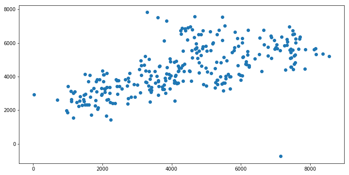

```python
plt.figure(figsize=(12,6))
plt.scatter(y_test,predictions)
```

The more linear the graph above is, the more accurate our predictive model is. In this case our predictive model could be better.

```python
from sklearn import metrics
```

```python
print('MAE:', metrics.mean_absolute_error(y_test, predictions))
print('MSE:', metrics.mean_squared_error(y_test, predictions))
print('RMSE:', np.sqrt(metrics.mean_squared_error(y_test, predictions)))
```

```
MAE: 1205.5387934364553
MSE: 2280168.2970345556
RMSE: 1510.022614742758
```

Plot below shows the diviation between our predicted results and true y values. We want the tallest bins to be close to zero.

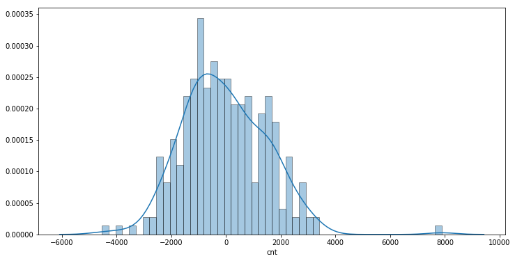

```python
plt.figure(figsize=(12,6))
sns.distplot((y_test-predictions),bins=50);
```